# UK Accidents

Adrian Sandru, Andrei Rizescu

5/11/2021

# Dataset description

Our dataset consists of data regarding UK road accidents from 2005 to 2014 and the circumstances in which they happened. The dataset is split in 3 sub-sets. The main set include information about the accident severity, number of casualties and many more. The second one offers valuable details about the vehicles involved, as well as driver information. The last set includes information about the victims of a specific accident. All sets are linked with a guide containing the text description of all variable code in the three files.

# Introduction

The selected dataset provides enough information so we mainly focus on a subset including the severity of the accidents and how they are influenced by external factors, the age of the drivers, and the location of these events.

# Data preparation

The data preparation consists in joining the main csvs with their lookup tables.

```r
library(tidyverse)
library(readxl)
library(factoextra)

Accidents <- read_csv("./data/Accidents0514.csv")
Casualties <- read_csv("./data/Casualties0514.csv")
Vehicles <- read_csv("./data/Vehicles0514.csv")

df <- merge(Accidents, Casualties, by='Accident_Index')
df <- merge(df, Vehicles, by='Accident_Index')


Location_code <- read_excel("./data/Road-Accident-Safety-Data-Guide.xls", sheet="Police Force")
df <- left_join(df, Location_code, by=c("Police_Force"="code"))
df <- rename(df, Location=label)
rm(Location_code)

Casualty_severity <- read_excel("./data/Road-Accident-Safety-Data-Guide.xls", sheet="Accident Severity")
df <- left_join(df, Casualty_severity, by=c("Casualty_Severity"="code"))
df <- rename(df, Casualty_Outcome=label)
rm(Casualty_severity)
```

# Gender vs severity of the accidents

```
## # A tibble: 9 x 3
## # Groups:   Gender [3]
##   Gender    Casualty_Outcome t_count
##   <chr>     <chr>              <int>
## 1 Female    Fatal               7146
## 2 Female    Serious            97212
## 3 Female    Slight           1140961
## 4 Male      Fatal              33578
## 5 Male      Serious           311952
## 6 Male      Slight           2483902
## 7 Not known Fatal               1256
## 8 Not known Serious            21669
## 9 Not known Slight            189871
```

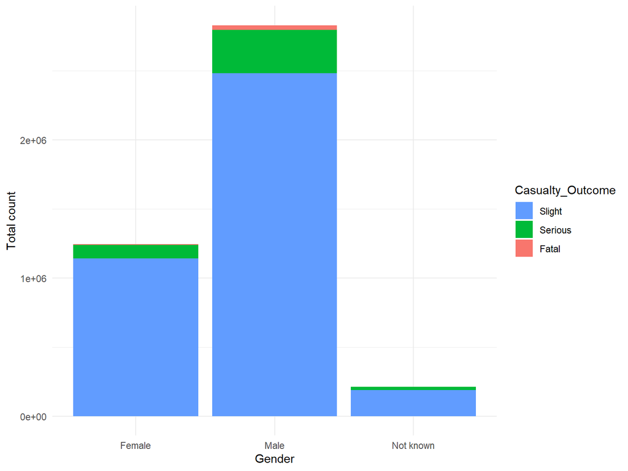